# Project 3 Client Report

Alvin Thomas

11/18/2019

# Introduction

The [Urban Ministries of Durham](http://www.umdurham.org/) (UMD) fights poverty and homeless by offering food, shelter, and a future to neighbors in need. Their mission is accomplished through three primary programs: a [community shelter](http://www.umdurham.org/what-we-do/shelter.html) to house homeless neighbors, a [community cafe](http://www.umdurham.org/what-we-do/cafe.html) that provides hot and cold meals three times a day, and a [food pantry and clothing closet](http://www.umdurham.org/what-we-do/food-pantry.html).

During the 2017-2018 [fiscal year](http://umdurham.org/assets/files/UMD_2018AnnualReport_Online.pdf), UMD provided 54,378 nights of shelter to homeless neighbors (792 unique individuals), served 248,028 meals through the community cafe, and provided clothing and groceries to over 500 households per month. Importantly, they ended homelessness for 243 individuals.

In collaboration with [Biostatistics 611](https://biodatascience.github.io/datasci611/), a course titled “Introduction to Data Science” at the University of North Carolina at Chapel Hill, UMD released several datasets of services provided.

# Study Aim

The purpose of this project is describe the population served by UMD’s emergency shelter.

## Client Gender

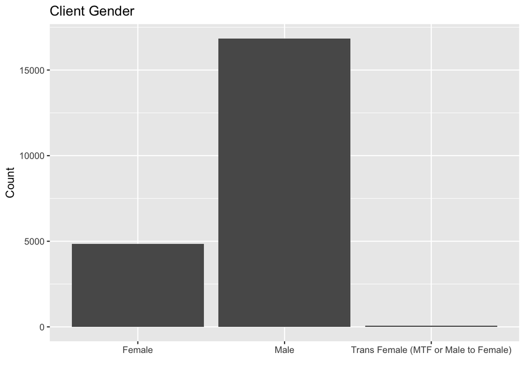

## Client Race

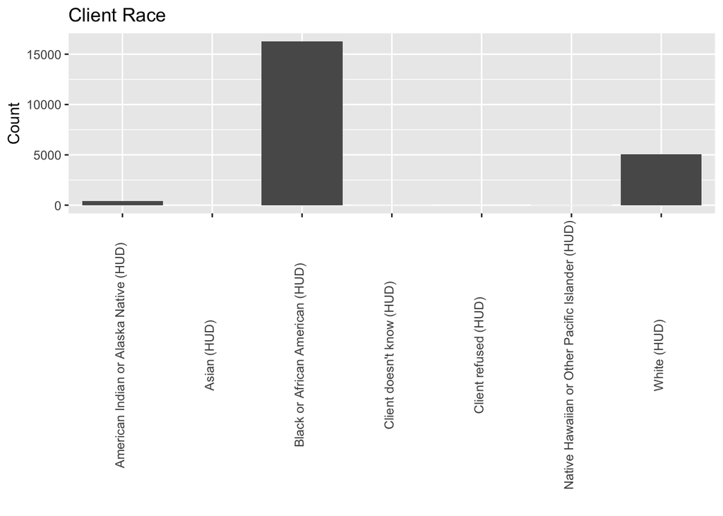

## Client Veteran Status

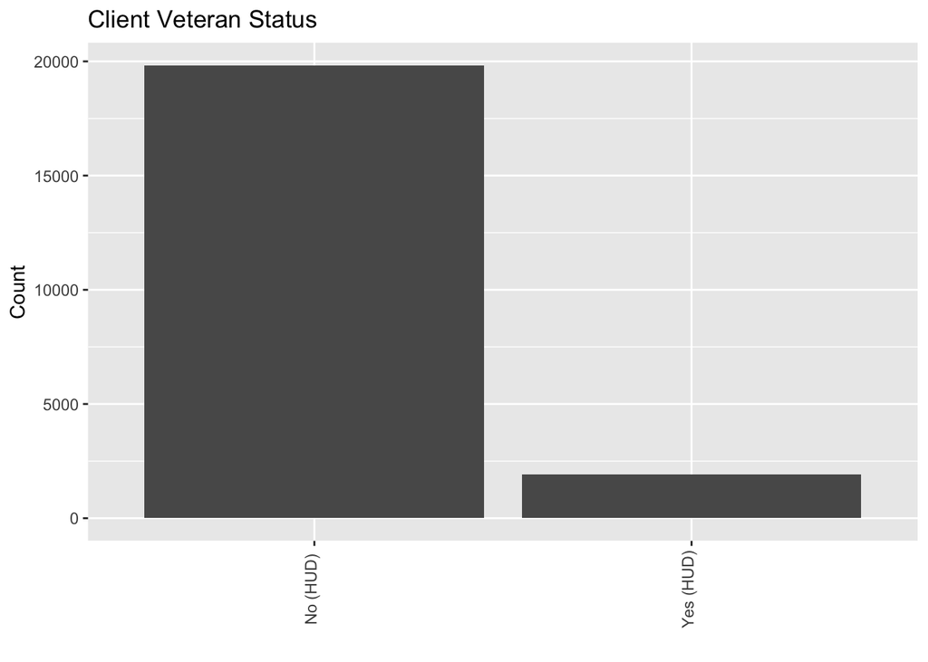

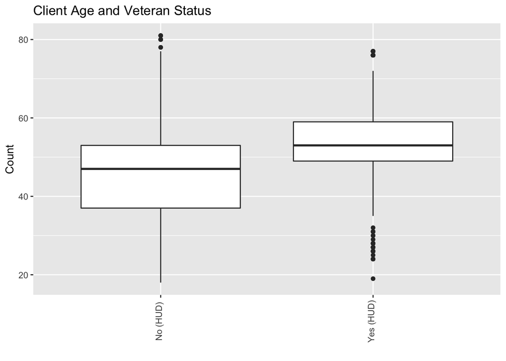

## Client Insurance Status

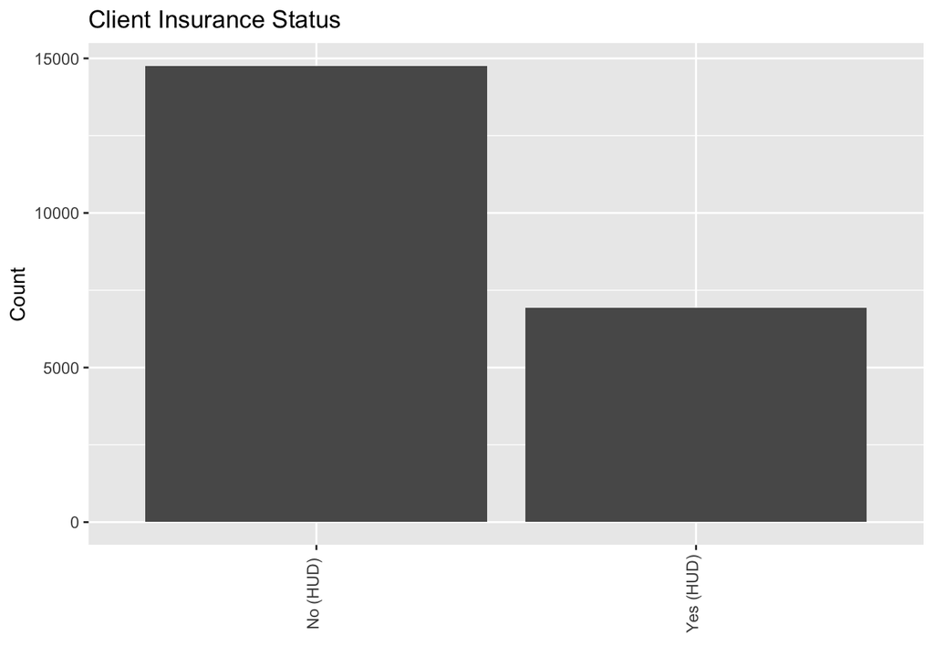

# Conclusion

We have described basic characterisics of the UMD homeless shelter neighbor. Veterans are more likely to be older.